# R Notebook

Loading libraries:

```r
library(neuralnet)
library(readxl)
library(caTools)
library(ggplot2)
library(gridExtra)
library(dplyr)
```

Problem-1: (Car Sales, Neural Networks) Load dataset.

```r
toyota <- read_excel('18 Toyota Corolla.xlsx', sheet=1)
```

Removing Id, Model, Cylinders and creating dummy variables for Fuel_type and Color:

```r
dummy_fuel <- data.frame(model.matrix(~toyota$Fuel_Type)[, c(2, 3)])
names(dummy_fuel) <- c('Diesel', 'Petrol')
toyota <- cbind(toyota, dummy_fuel)

dummy_color <- data.frame(model.matrix(~toyota$Color)[, 2:10])
names(dummy_color) <- c('Black', 'Blue' ,'Green', 'Grey', 'Red', 'Silver', 'Violet', 'White', 'Yellow')
toyota <- cbind(toyota, dummy_color)

toyota <- toyota[ ,-c(1,2,8,11,15)]

#toyota$CC <- as.numeric(toyota$CC)
```

*A common function to return the mean and standard deviation of the columns*

```r
get_stats = function(df){
        mean_df = df %>% summarise_all(list(name = ~mean(., na.rm = TRUE)))
        std_df = df %>% summarise_all(list(name = ~sd(., na.rm = TRUE)))
        stats_df = rbind(mean_df, std_df)
        names(stats_df) = names(df)
        rownames(stats_df) = c('Mean', 'Std Dev')
        return(stats_df)
}
```

*A common function to return the scaled data*

```r
get_scaled_data = function(stats, df){
        new_df = data.frame(matrix(0, nrow = nrow(df), ncol = ncol(df)))
        names(new_df) = names(df)
        for(col in names(df)){
                new_df[, col] = (df[, col] - stats[1, col]) / stats[2, col]
        }
        return(new_df)
}
```

Partitioning the data into training and testing datasets

```r
set.seed(123)
splitted_set <- sample.split(toyota$Price, SplitRatio = 0.75)
toyota_train <- subset(toyota, subset = splitted_set)
toyota_test <- subset(toyota, subset = !splitted_set)
```

Getting the stats for training data and scaling training and testing data.

```r
stats <- get_stats(toyota_train)
toyota_train <- get_scaled_data(stats, toyota_train)
toyota_test <- get_scaled_data(stats, toyota_test)
```

Separating predictors of train and test data:

```r
response <- c(which(colnames(toyota_train) == 'Price'))
toyota_train_predictors <- toyota_train[,-response]
toyota_test_predictors <- toyota_test[,-response]
```

1. What happens to the RMS error (or Sum of Squares Error) for the training data as the value of threshold decreases? For this problem we will keep number of hidden nodes constant (15) and vary threshold, and see the effects on RMSE for training data.

```r
set.seed(200)

toyota_nn <- function(threshold, hidden){
toyota_nn <- neuralnet(Price~., data = toyota_train, linear.output = F, threshold=threshold, hidden = hidden, stepmax=10**6)
}

rms <- function(a, b){
  return(sqrt(mean((a-b)^2)))
}

train_rms <- function(fit){
  fit_train <- neuralnet::compute(fit, toyota_train_predictors)
  fit_train_rms <- rms(fit_train$net.result, toyota_train$Price)
  return(fit_train_rms)
}

fit_thr_1 <- toyota_nn(1, 15)
fit_thr_0.1 <- toyota_nn(0.1, 15)
fit_thr_0.05 <- toyota_nn(0.05, 15)
fit_thr_0.01 <- toyota_nn(0.01, 15)
fit_thr_0.005 <- toyota_nn(0.005, 15)
fit_thr_0.001 <- toyota_nn(0.001, 15)
fit_thr_0.0001 <- toyota_nn(0.0001, 15)

rmse_train <- data.frame('Threshold'=c(1, 0.1, 0.05, 0.01, 0.005, 0.001, 0.0001),
                            'RMSE'=c(train_rms(fit_thr_1), train_rms(fit_thr_0.1), train_rms(fit_thr_0.05), train_rms(fit_thr_0.01), train_rms(fit_thr_0.005), train_rms(fit_thr_0.001), train_rms(fit_thr_0.0001)))

cat(paste0("RMSE for training when threshold 1: ", train_rms(fit_thr_1), '\n',
           "RMSE for training when threshold 0.1: ", train_rms(fit_thr_0.1), '\n',
           "RMSE for training when threshold 0.05: ", train_rms(fit_thr_0.05), '\n',
           "RMSE for training when threshold 0.01: ", train_rms(fit_thr_0.01), '\n',
           "RMSE for training when threshold 0.005: ", train_rms(fit_thr_0.005), '\n',
           "RMSE for training when threshold 0.001: ", train_rms(fit_thr_0.001), '\n',
           "RMSE for training when threshold 0.0001: ", train_rms(fit_thr_0.0001)))
```

```
RMSE for training when threshold 1: 0.741768882288791
RMSE for training when threshold 0.1: 0.730700130878578
RMSE for training when threshold 0.05: 0.728739288449289
RMSE for training when threshold 0.01: 0.728365588758244
RMSE for training when threshold 0.005: 0.728279383276596
RMSE for training when threshold 0.001: 0.727645077368723
RMSE for training when threshold 0.0001: 0.727881127410621
```

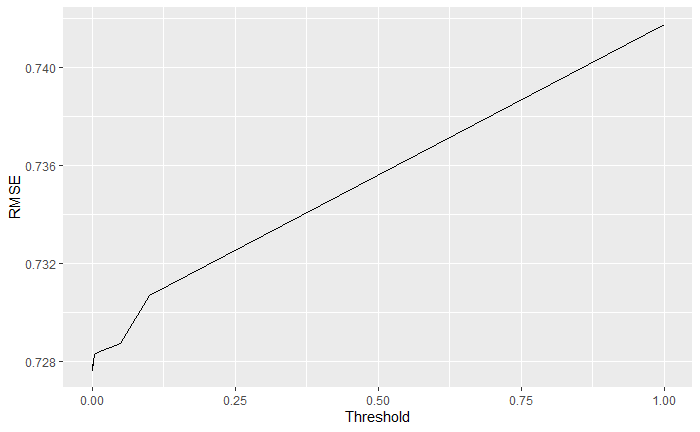

```r
ggplot(rmse_train) + geom_line(aes(x=Threshold, y=RMSE))
```

As we can see from the plot, decrease in threshold decreases RMS error for training dataset.

2. What happens to the RMS error Sum of Squares Error for the validation data? For this problem we will keep number of hidden nodes constant (15) and vary threshold, and see the effects on RMSE for test data.

```r
set.seed(00)

test_rms <- function(fit){
  fit_test <- neuralnet::compute(fit, toyota_test_predictors)
  fit_test_rms <- rms(fit_test$net.result, toyota_test$Price)
  return(fit_test_rms)
}

rmse_test <- data.frame('Threshold'=c(1, 0.1, 0.05, 0.01, 0.005, 0.001, 0.0001),
                        'RMSE'=c(test_rms(fit_thr_1), test_rms(fit_thr_0.1), test_rms(fit_thr_0.05),test_rms(fit_thr_0.01), test_rms(fit_thr_0.005), test_rms(fit_thr_0.001), test_rms(fit_thr_0.0001)))

cat(paste0("RMSE for test data when threshold 1: ", test_rms(fit_thr_1), '\n',
           "RMSE for test data when threshold 0.1: ", test_rms(fit_thr_0.1), '\n',
           "RMSE for test data when threshold 0.05: ", test_rms(fit_thr_0.05), '\n',
           "RMSE for test data when threshold 0.01: ", test_rms(fit_thr_0.01), '\n',
           "RMSE for test data when threshold 0.005: ", test_rms(fit_thr_0.005), '\n',
           "RMSE for test data when threshold 0.001: ", test_rms(fit_thr_0.001), '\n',
           "RMSE for test data when threshold 0.0001: ", test_rms(fit_thr_0.0001)))
```

```
RMSE for test data when threshold 1: 0.638392924174827
RMSE for test data when threshold 0.1: 0.637140196916535
RMSE for test data when threshold 0.05: 0.639404354704044
RMSE for test data when threshold 0.01: 0.640700858090798
RMSE for test data when threshold 0.005: 0.641477379064743
RMSE for test data when threshold 0.001: 0.642993469174652
RMSE for test data when threshold 0.0001: 0.651929091855278
```

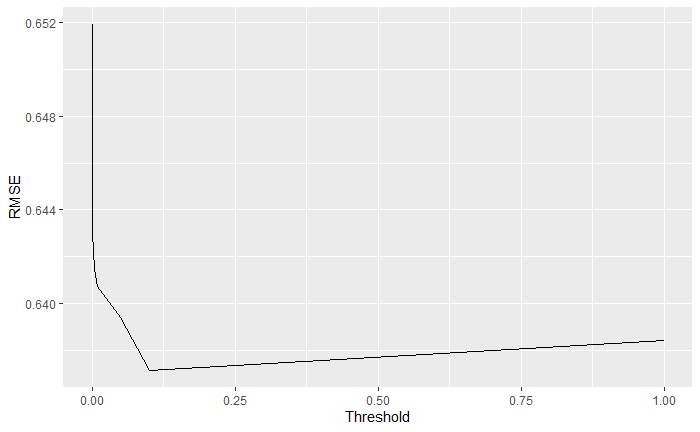

```r
ggplot(rmse_test) + geom_line(aes(x=Threshold, y=RMSE))
```

##Answer: We can see that as we decrease the value of threshold RMSE increases for validation data set.

3. Conduct an experiment to assess the effect of changing the number of hidden layer nodes (default 1), e.g., 1,2,4,8. For this problem we will change number of hidden layer nodes and keep threshold constant (0.5) and check how model performs on test data.

```r
set.seed(200)

fit_nd_1 <- toyota_nn(0.5, 1)
test_rms(fit_nd_1)
```

```
[1] 0.642245
```

```r
fit_nd_2 <- toyota_nn(0.5, 2)
test_rms(fit_nd_2)
```

```
[1] 0.6374549
```

```r
fit_nd_4 <- toyota_nn(0.5, 4)
test_rms(fit_nd_4)
```

```
[1] 0.6356049
```

```r
fit_nd_8 <- toyota_nn(0.5, 8)
test_rms(fit_nd_8)
```

```
[1] 0.6368312
```

```r
rmse_test <- data.frame('Nodes'=c(1,2,4,8),
                        'Train'=c(train_rms(fit_nd_1), train_rms(fit_nd_2), train_rms(fit_nd_4),
                            train_rms(fit_nd_8)),
                        'Test'=c(test_rms(fit_nd_1), test_rms(fit_nd_2), test_rms(fit_nd_4),
                            test_rms(fit_nd_8)))

cat(paste0("RMSE for test data when hidden layer nodes 1: ", test_rms(fit_nd_1), '\n',
           "RMSE for test data when hidden layer nodes 2: ", test_rms(fit_nd_2), '\n',
           "RMSE for test data when hidden layer nodes 4: ", test_rms(fit_nd_4), '\n',
           "RMSE for test data when hidden layer nodes 8: ", test_rms(fit_nd_8)))
```

```
RMSE for test data when hidden layer nodes 1: 0.642244960285263
RMSE for test data when hidden layer nodes 2: 0.637454887589806
RMSE for test data when hidden layer nodes 4: 0.635604899212248
RMSE for test data when hidden layer nodes 8: 0.636831195647416
```

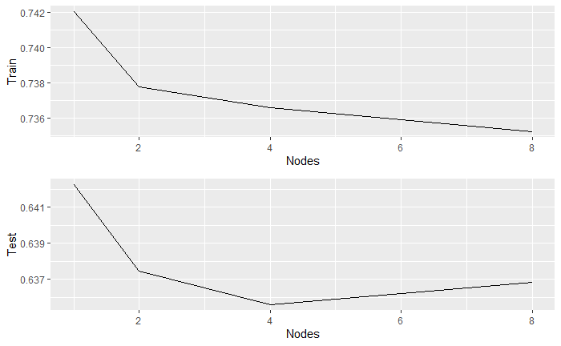

```r
train_plot <- ggplot(rmse_test) + geom_line(aes(x=Nodes, y=Train))
test_plot <- ggplot(rmse_test) + geom_line(aes(x=Nodes, y=Test))
grid.arrange(train_plot, test_plot)
```

4. Conduct a similar experiment to assess the effect of changing the number of layers from 1 to 2 in the network. For this problem we will keep constant threshold of 0.5 and change number of hidden layers from 1 to 2 and check how model performs on test data. Each hidden layer will have 5 nodes.

```r
set.seed(200)

fit_hl_1 <- toyota_nn(0.5, 5)

fit_hl_2 <- toyota_nn(0.5, c(5,5))

cat(paste0("RMSE for test data when number of layers 1: ", test_rms(fit_hl_1), '\n',
           "RMSE for test data when number of layers 2: ", test_rms(fit_hl_2)))
```

```
RMSE for test data when number of layers 1: 0.638282888296242
RMSE for test data when number of layers 2: 0.641938989430504
```

5. Study the effect of gradient descent step size (learningrate) on the training process and the network performance. For this problem we will keep number of hidden nodes (1) and threshold (0.5) constant and vary learning rate, and see the effects on RMSE for test data.

```r
set.seed(100)

toyota_nnlr <- function(learningrate){
toyota_nnlr <- neuralnet(Price~., data = toyota_train, linear.output = F, threshold=0.5, hidden = 1, algorithm='rprop+', err.fct='sse', stepmax=10**6, learningrate=learningrate)
}

fit_lr_1 <- toyota_nnlr(1)
fit_lr_0.1 <- toyota_nnlr(0.1)
fit_lr_0.05 <- toyota_nnlr(0.05)
fit_lr_0.01 <- toyota_nnlr(0.01)
fit_lr_0.005 <- toyota_nnlr(0.005)
fit_lr_0.001 <- toyota_nnlr(0.001)
fit_lr_0.0001 <- toyota_nnlr(0.0001)

rmse_test <- data.frame('Learning_Rate'=c(1, 0.1, 0.05, 0.01, 0.005, 0.001, 0.0001),
                        'RMSE'=c(test_rms(fit_lr_1), test_rms(fit_lr_0.1), test_rms(fit_lr_0.05),
                            test_rms(fit_lr_0.01), test_rms(fit_lr_0.005), test_rms(fit_lr_0.001), test_rms(fit_lr_0.0001)))

cat(paste0("RMSE for training when learning rate is 1: ", test_rms(fit_lr_1), '\n',
           "RMSE for training when learning rate is 0.1: ", test_rms(fit_lr_0.1), '\n',
           "RMSE for training when learning rate is 0.05: ", test_rms(fit_lr_0.05), '\n',
           "RMSE for training when learning rate is 0.01: ", test_rms(fit_lr_0.01), '\n',
           "RMSE for training when learning rate is 0.005: ", test_rms(fit_lr_0.005), '\n',
           "RMSE for training when learning rate is 0.001: ", test_rms(fit_lr_0.001), '\n',
           "RMSE for training when threshold 0.0001: ", test_rms(fit_lr_0.0001)))
```

```
RMSE for training when learning rate is 1: 0.645281008074199
RMSE for training when learning rate is 0.1: 0.670482746806434
RMSE for training when learning rate is 0.05: 0.641049762052882
RMSE for training when learning rate is 0.01: 0.640907910020758
RMSE for training when learning rate is 0.005: 0.647627870126236
RMSE for training when learning rate is 0.001: 0.637612014436674
RMSE for training when threshold 0.0001: 0.648706001125227
```

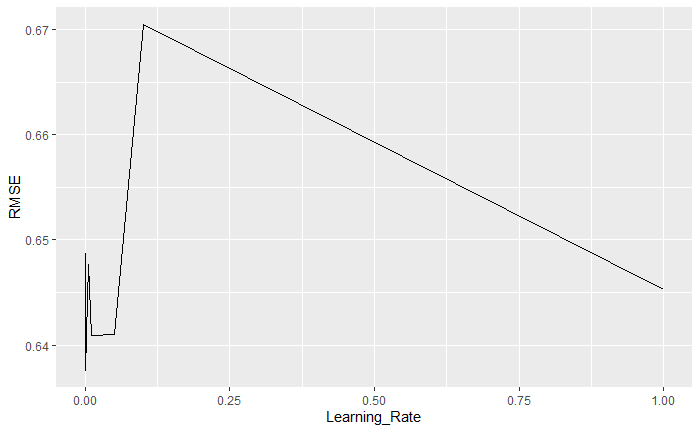

```r
ggplot(rmse_test) + geom_line(aes(x=Learning_Rate, y=RMSE))
```